# Introduction to Research Methods

Stijn Masschelein

March, 2018

# 1 Measuring and Theory

## 1.1 Previously on CEO compensation

- CEOs have a multiplicative effect on firm value
- Different theories lead to different relations
  - linear relation between wage and size
  - log-log relation between wage and size
- If a theory is too complicated, we can often use simulations instead of math
- Today, I won’t give you all the details.

The linear relation follows from a theory that assumes that CEOs grow the company and CEOs have a multiplicative effect on the value of the firm. The log-log relation follows from the assumption that CEOs have a multiplicative effect on firm value and firms and CEOs match (on size and talent).

## 1.2 CEO Incentive Compensation

> Jensen and Murphy (1990) estimated $–$ incentives and showed that the CEO loses only $3.25 for every $1,000 loss in firm value, an effective equity stake of only 0.325 percent. They interpreted this stake as too low to be reconciled with optimal contracting, and thus concluded that CEOs are “paid like bureaucrats”

From Edmans and Gabaix (2016)

## 1.3 CEO effects on firm value

- Independent of firm size
  - Perks (e.g. corporate jet)
- Multiplicative
  - Good decision are rolled out for the entire firm (e.g. strategy)
  - More cash to divert in larger firm

## 1.4 CEO preferences or cost of working

- Additive with compensation
  - Working has a monetary cost, e.g. opportunity cost.
  - Foregoing leisure time
- Multiplicative with compensation
  - If you are rich, one vacation day is more valuable
- opportunity cost = “Instead of managing a company, I could be investing in X” with X your preferred investment vehicle.
- One vacation day is more valuable = Elon Musk’s or Richard Branson’s days off sound pretty bad ass.

## 1.5 Optimal CEO incentives

1. Additative effect on firm size
   - Constant equity compensation: $-$ incentives
2. Multiplicative effect on firm size
   - $-% incentives
3. Multiplicative effect on firm size and multiplicative preferences
   - %-% incentives
- Optimal CEO incentives *from a optimal contracting* point of view with additional assumptions. This is important if we want to investigate whether CEOs have the appropriate pay for performance sensitivity according to optimal contracting theory.
- Multiplicative effect on firm size means that for each good decision the value of the firm increases with a certain percentage.

## 1.6 Measuring pay-performance sensitivity: Total wealth not cash payments

### 1.6.1 Theoretically

1. $\frac{\partial W}{\partial r} \frac{1}{V_0}$
2. $\frac{\partial W}{\partial r}$
3. $\frac{\partial W}{\partial r} \frac{1}{W_0}$

The partial derivative indicates the change in wealth ($) for a change in returns (%).

Mathematical note:
$$ln(W) - ln(W_0) = ln(\frac{W}{W_0})$$

### 1.6.2 Empirically

1. $\frac{\Delta Wealth}{\Delta Firm\ Value}$
2. $\frac{\Delta Wealth}{\Delta ln(Firm\ Value)}$
3. $\frac{\Delta ln(Wealth)}{\Delta ln(Firm\ Value)}$

So wealth-performance sensitivity is actually a better description.

# 2 What does the data say?

## 2.1 Load the data and the packages

### 2.1.1 Data

```r
library(tidyverse)
library(ggplot2)
folder = "~/Dropbox/R/wrds/data/"
us_comp = readRDS(paste0(folder, "us-compensation.RDS")) %>%
  rename(total_comp = tdc1)
us_value = readRDS(paste0(folder, "us-value.RDS")) %>%
  rename(year = fyear, market_value = mkvalt)
```

## 2.2 Join the two datasets

```r
us_comp_limit = select(us_comp, gvkey, execid, year, shares, total_comp)
us_comp_value = left_join(us_comp_limit, us_value,
                          by = c("year", "gvkey")) %>%
  filter(!is.na(market_value) & !(is.na(shares))) %>%
  mutate(wealth = shares * market_value / 100)

max(us_comp_value$market_value)/1e3
```

```
## [1] 790.0501
```

```r
max(us_comp_value$wealth)/1e3
```

```
## [1] 72.06337
```

Apple’s current market value hovers around $890 billion. Jeff Bezos is worth around $100 billion. So it’s not a terrible first attempt.

## 2.3 Shares as a function of firm size

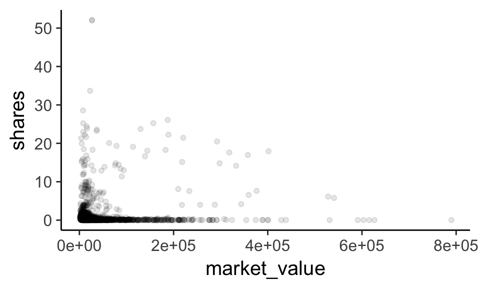

```r
shares_size = ggplot(data = us_comp_value,
                     aes(x = market_value, y = shares)) +
  geom_point(alpha = .10)
plot(shares_size)
```

## 2.4 Shares as a function of firm size (2)

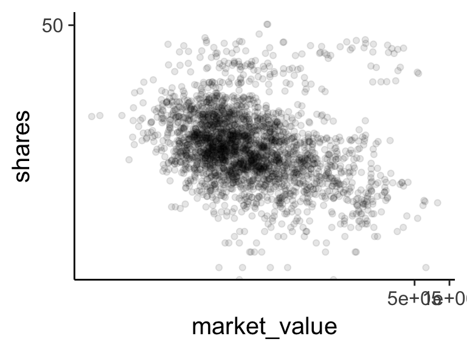

```r
shares_size_log = shares_size +
  scale_x_continuous(trans = "log",
                     breaks = scales::pretty_breaks(n = 3)) +
  scale_y_continuous(trans = "log",
                     breaks = scales::pretty_breaks(n = 3))
plot(shares_size_log)
```

I wonder whether the cloud of points at the top of the graph are founder CEOs. They might keep a larger amount of shares and optimal contracting might have a different logic here. I will ignore this issue further onwards.

## 2.5 Create lagged variables

```r
us_comp_value = group_by(us_comp_value, gvkey, execid) %>%
  arrange(year) %>%
  mutate(prev_market_value = lag(market_value),
         prev_wealth = lag(wealth),
         prev_comp = lag(total_comp)) %>%
  ungroup() %>%
  mutate(change_market_value = market_value - prev_market_value,
         change_wealth = wealth - prev_wealth,
         change_comp = total_comp - prev_comp,
         change_log_value = log(market_value) - log(prev_market_value),
         change_log_wealth = log(wealth) - log(prev_wealth),
         change_log_comp = log(total_comp) - log(prev_comp)) %>%
  mutate(change_log_wealth =
           ifelse(is.infinite(change_log_wealth),
                  min(change_log_wealth[is.finite(change_log_wealth)]),
                  change_log_wealth)) %>%
  arrange(gvkey)
```

The last addition is a bit of hack. There is one wealth change that is infinite at the log value. That can happen when a CEO ends up with 0 shares.

## 2.6 Comparison to the literature

```r
jensen_murphy90 = lm(change_comp ~ change_market_value,
                     data = us_comp_value)
hall_liebman98 = lm(change_log_comp ~
                    I(change_market_value/prev_market_value),
                    data = us_comp_value)
hall_liebman98_alt = lm(change_log_comp ~ change_log_value,
                        data = us_comp_value)
core_guay_thomas05 = lm(change_log_wealth ~ change_log_value,
                         data = us_comp_value)
```

### 2.6.1 Coefficients

```r
coef(jensen_murphy90)[2]
```

```
## change_market_value
##          0.04214457
```

```r
coef(hall_liebman98)[2]
```

```
## I(change_market_value/prev_market_value)
##                                 0.231437
```

```r
coef(hall_liebman98_alt)[2]
```

```
## change_log_value
##        0.3047814
```

```r
coef(core_guay_thomas05)[2]
```

```
## change_log_value
##         0.686048
```

## 2.7 Comparison plot

### 2.7 Data

```r
data_comparison = select(us_comp_value, change_comp, change_market_value,
                         change_log_comp, change_log_value,
                         change_log_wealth) %>%
  filter(complete.cases(.))
n = nrow(data_comparison)
data_comparison = bind_rows(data_comparison, data_comparison,
                            data_comparison) %>%
  mutate(analysis = c(rep("jensen_murphy90", n),
                     rep("hall_liebman98_alt", n),
                     rep("core_guay_thomas05", n))) %>%
  mutate(incentive = recode(analysis,
                            "jensen_murphy90" = change_comp,
                            "hall_liebman98_alt" = change_log_comp,
                            "core_guay_thomas05" = change_log_wealth),
         performance = recode(analysis,
                              "jensen_murphy90" = change_market_value,
                              "hall_liebman98_alt" = change_log_value,
                              "core_guay_thomas05" = change_log_value)) %>%
  select(analysis, performance, incentive)
```

### 2.7.1 Plot

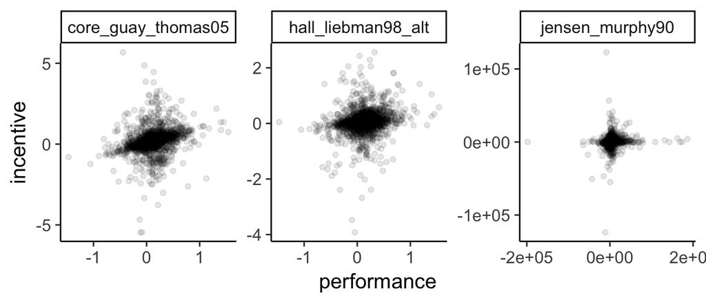

```r
comparison_plot = ggplot(data_comparison,
                         aes(x = performance, y = incentive)) +
  geom_point(alpha = .1) +
  facet_wrap( ~ analysis, ncol = 3, scales = "free") +
  scale_x_continuous(breaks = scales::pretty_breaks(n = 3)) +
  scale_y_continuous(breaks = scales::pretty_breaks(n = 3))
print(comparison_plot)
```

# 3 The point

## 3.1 Libby boxes

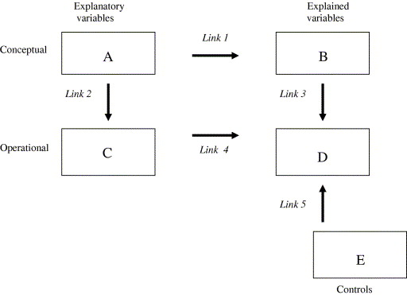

# 4 Hypothesis testing

## 4.1 Are incentives independent of size?

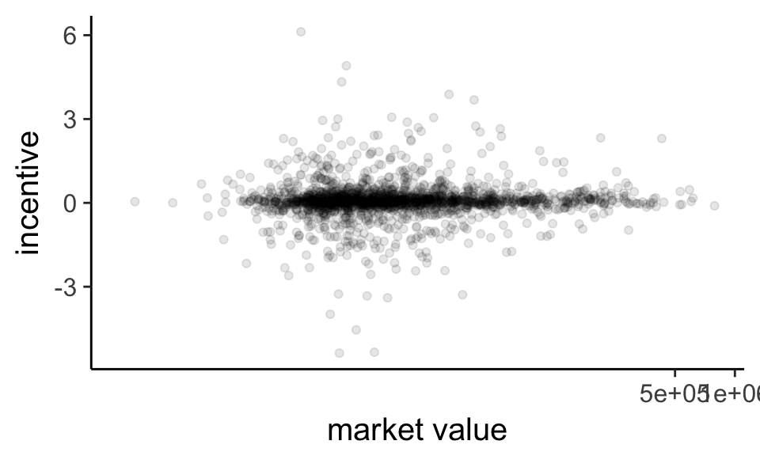

```r
hypothesis = ggplot(us_comp_value,
                    aes(y = change_log_wealth - change_log_value,
                        x = market_value)) +
  geom_point(alpha = .1) +
  scale_x_continuous(trans = "log", limits = c(NA, NA),
                     breaks = scales::pretty_breaks(n = 3)) +
  xlab("market value") +
  ylab("incentive")
print(hypothesis)
```

## 4.2 Null hypothesis

- sensitivity = $ln(\frac{W/W_0}{V/V_0})$
- market value = $V_0$

### 4.2 No relation = randomly reshuffling the values

```r
data_hypo = mutate(us_comp_value,
                   sensitivity = change_log_wealth - change_log_value) %>%
  select(sensitivity, market_value) %>%
  filter(complete.cases(.))
true_cor = cor(data_hypo$sensitivity, data_hypo$market_value)
rand_cor = cor(data_hypo$sensitivity, sample(data_hypo$market_value))
print(round(c(true_cor, rand_cor), 2))
```

```
## [1] 0.03 0.03
```

### 4.2.1 Simulation of no effect

```r
simulate_cor = function(data){return(cor(data$sensitivity,
                                         sample(data$market_value)))}
rand_cor = replicate(1e4, simulate_cor(data_hypo))
```

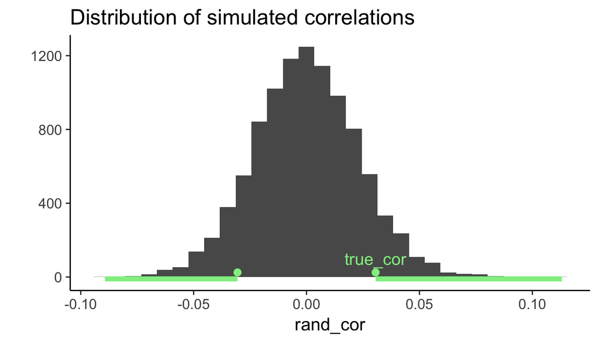

## 4.3 P-value

### 4.3.1 Correlation

```r
pvalue_sim =  mean(ifelse(abs(rand_cor) > abs(true_cor), 1, 0))
cor = cor.test(data_hypo$sensitivity, data_hypo$market_value)
pvalue_cor = cor$p.value
print(c(pvalue_cor, pvalue_sim), dig = 3)
```

```
## [1] 0.181 0.179
```

### 4.3.2 Regression and correlation

$$y \sim \mathcal{N}(\alpha + \beta x, \sigma) \\
\beta = \frac{sd(y)}{sd(x)} cor(x, y)$$

```r
regr_sens = lm(sensitivity ~ market_value, data = data_hypo)
print(coefficients(summary(regr_sens)), dig = 3)
```

```
##              Estimate Std. Error t value Pr(>|t|)
## (Intercept)  5.37e-02   1.86e-02    2.89  0.00392
## market_value 3.34e-07   2.49e-07    1.34  0.18060
```

We can redo the whole thing with compensation-performance sensitivity.

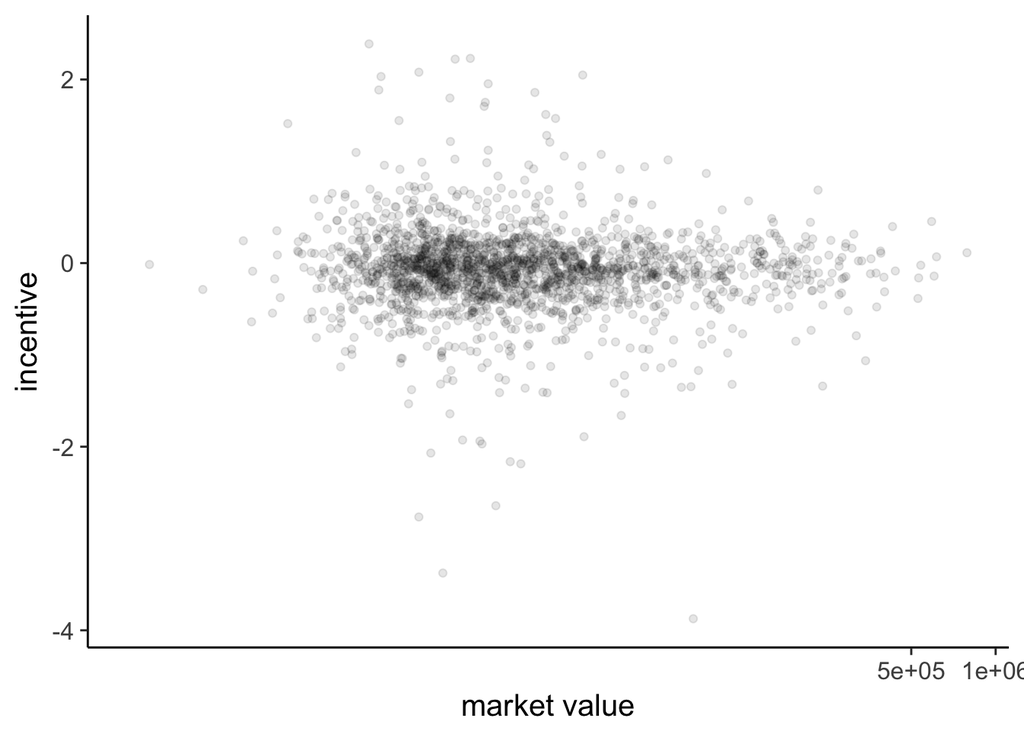

```r
hypothesis = ggplot(us_comp_value,
                    aes(y = change_log_comp - change_log_value,
                        x = market_value)) +
  geom_point(alpha = .1) +
  scale_x_continuous(trans = "log", limits = c(NA, NA),
                     breaks = scales::pretty_breaks(n = 3)) +
  xlab("market value") +
  ylab("incentive")
print(hypothesis)
```

```r
data_hypo = mutate(us_comp_value,
                   sensitivity = change_log_comp - change_log_value) %>%
  select(sensitivity, market_value) %>%
  filter(complete.cases(.))
true_cor = cor(data_hypo$sensitivity, data_hypo$market_value)
rand_cor = cor(data_hypo$sensitivity, sample(data_hypo$market_value))
print(round(c(true_cor, rand_cor), 2))
```

```
## [1] -0.02  0.02
```

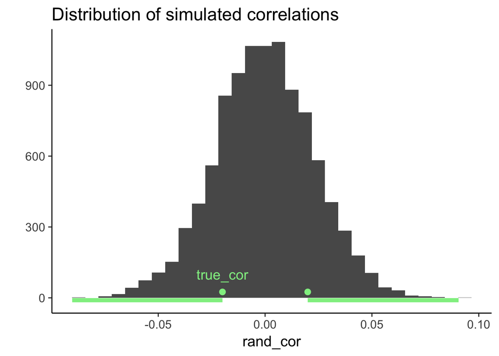

```r
rand_cor = replicate(1e4, simulate_cor(data_hypo))

hist_sim= qplot(rand_cor) +
  geom_point(aes(y = 25, x = c(-true_cor, true_cor)), size = 2.5,
             col = "lightgreen") +
  annotate(geom = "text", y = 100, x = true_cor, size = 5,
           col = "lightgreen", label = "true_cor") +
  geom_segment(aes(y = -10, yend = -10,
                   x = abs(true_cor), xend = max(rand_cor)),
               col = "lightgreen", size = 2) +
  geom_segment(aes(y = -10, yend = -10,
                   x = - abs(true_cor), xend = min(rand_cor)),
               col = "lightgreen", size = 2) +
  ylab("") +
  ggtitle("Distribution of simulated correlations")
print(hist_sim)
```

```r
pvalue_sim =  mean(ifelse(abs(rand_cor) > abs(true_cor), 1, 0))
cor = cor.test(data_hypo$sensitivity, data_hypo$market_value)
pvalue_cor = cor$p.value
print(c(pvalue_cor, pvalue_sim), dig = 3)
```

```
## [1] 0.383 0.376
```

```r
regr_sens = lm(sensitivity ~ market_value, data = data_hypo)
print(coefficients(summary(regr_sens)), dig = 3)
```

```
##               Estimate Std. Error t value Pr(>|t|)
## (Intercept)  -6.79e-02   1.20e-02  -5.656 1.78e-08
## market_value -1.40e-07   1.61e-07  -0.873 3.83e-01
```

## 4.4 Summary p-value

- Assuming the null hypothesis is true, how likely is it to get a value at least as extreme as the observed value
- 99.99% of all studies are interested in the alternative hypothesis not the null hypothesis.
- We can use simulations but they become time consuming in complicated scenarios.
- We can use additional assumptions but they become less robust in complicated scenarios.

# 5 Assignment

## 5.1 Test